# Reproductive Phenology of PBs

Pat Dumandan

2/27/2021

## Goal: Identify how the proportion of breeding individuals vary across all months in control vs exclosure plots

*when do the proportions synchronize and/or diverge at the different treatment plots?*  
*methods employed: GAM and change point model*

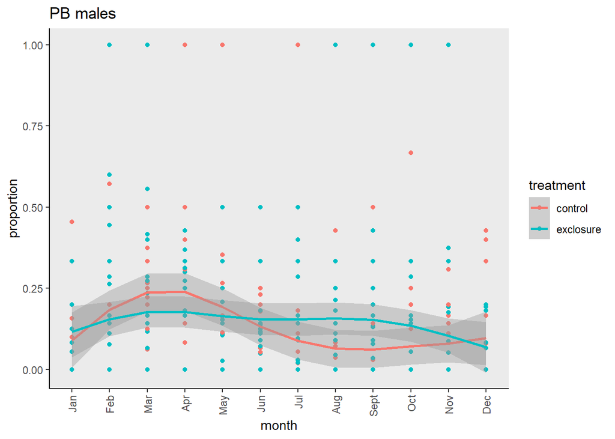

```r
ggplot(PB_dat_M, aes(y=proportion, x=month, col=treatment)) +
  geom_point() +
  stat_smooth(method = 'gam', formula = y ~ s(x))+
  ggtitle("PB males")+
  scale_x_discrete(name="month", limits=c("Jan", "Feb", "Mar", "Apr","May", "Jun",
                                          "Jul", "Aug", "Sept", "Oct", "Nov", "Dec"))+
  theme(axis.text.x= element_text(angle = 90, vjust=0.5, hjust=1),
        panel.border = element_blank(), panel.grid.major = element_blank(),
        panel.grid.minor = element_blank(), axis.line = element_line(colour = "black"))
```

### **PB control plots**

```r
PB_gam_con=PB_dat_M%>%
  filter(treatment=="control")%>%
  mutate(date=as.POSIXct(paste(month, "15", year, sep="-"), format="%m-%d-%Y"))
```

**Data Visualization**

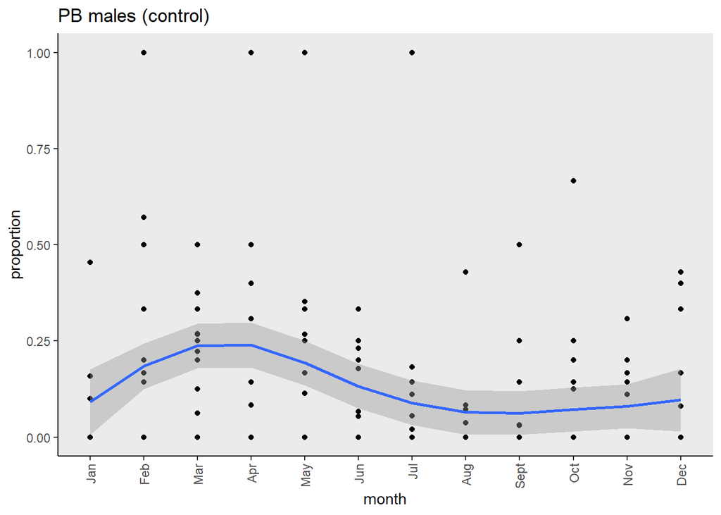

```r
ggplot(PB_gam_con, aes(y=proportion, x=month)) +
  geom_point() +
  stat_smooth(method = 'gam', formula = y ~ s(x))+
  ggtitle("PB males (control)")+
  scale_x_discrete(name="month", limits=c("Jan", "Feb", "Mar", "Apr","May", "Jun",
                                          "Jul", "Aug", "Sept", "Oct", "Nov", "Dec"))+
  theme(axis.text.x= element_text(angle = 90, vjust=0.5, hjust=1),
        panel.border = element_blank(), panel.grid.major = element_blank(),
        panel.grid.minor = element_blank(), axis.line = element_line(colour = "black"))
```

**GAM with autocorrelation structure**

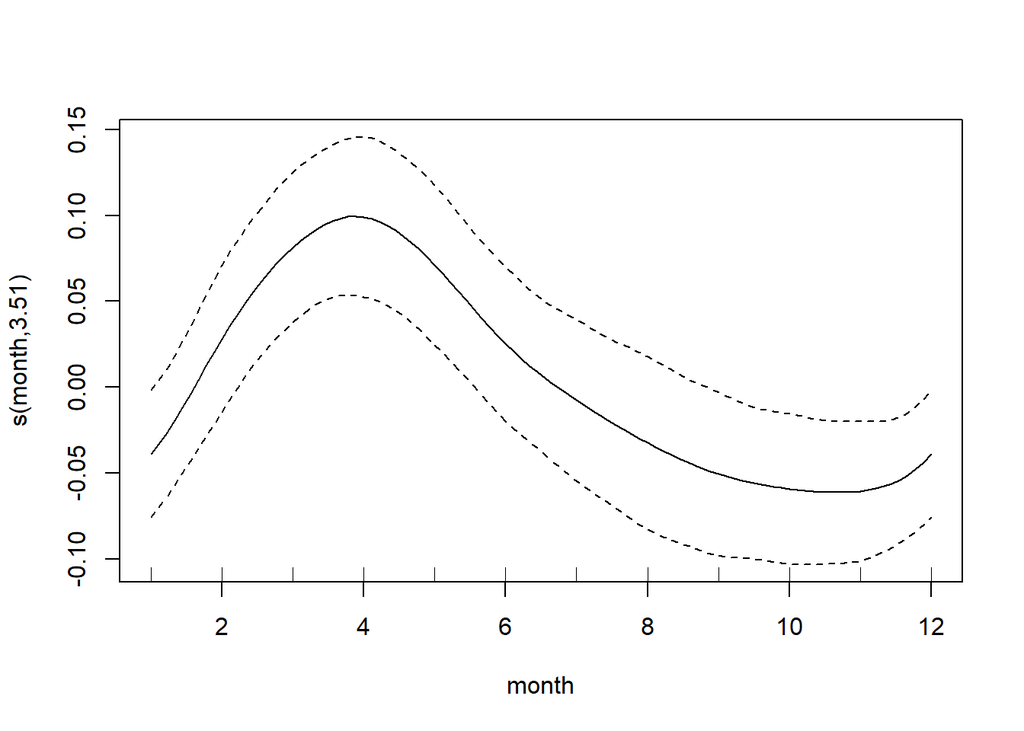

```r
m1=gamm(proportion~s(month, bs="cc", k=12), data=PB_gam_con, correlation = corARMA(form= ~1|year, p=2))
plot(m1$gam)
```

```r
summary(m1$gam)
```

```
##
## Family: gaussian
## Link function: identity
##
## Formula:
## proportion ~ s(month, bs = "cc", k = 12)
##
## Parametric coefficients:
##             Estimate Std. Error t value Pr(>|t|)
## (Intercept)  0.12391    0.01924   6.442 1.02e-09 ***
## ---
## Signif. codes:  0 '***' 0.001 '**' 0.01 '*' 0.05 '.' 0.1 ' ' 1
##
## Approximate significance of smooth terms:
##            edf Ref.df    F  p-value
## s(month) 3.515     10 2.49 9.11e-06 ***
## ---
## Signif. codes:  0 '***' 0.001 '**' 0.01 '*' 0.05 '.' 0.1 ' ' 1
##
## R-sq.(adj) =  0.0957
##   Scale est. = 0.035769  n = 187
```

#### Notes:

- seems like there is a clear period of high breeding intensity around Feb-Apr in control plots, which coincides with the hot and wet (summer) season? and with the underlying data
- figure out what the y-lab is in the gam viz
- figure out what this warning message means: saturated likelihood may be inaccurate when I try family=betar(link=“logit”), which also gives negative values for variance explained

**Calculate derivatives: to identify period of change**

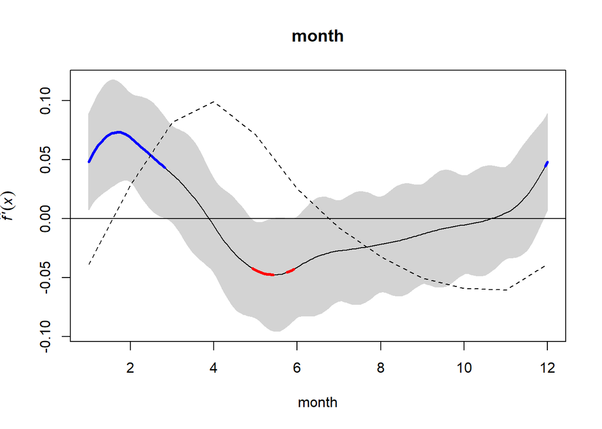

```r
tmpf <- tempfile()
download.file("https://gist.github.com/gavinsimpson/e73f011fdaaab4bb5a30/raw/82118ee30c9ef1254795d2ec6d356a664cc138ab/Deriv.R",tmpf)
source(tmpf)

want=seq(1, nrow(PB_gam_con), length.out = 200)
pdat=with(PB_gam_con, data.frame(year=year[want], month=month[want]))
p2=predict(m1$gam, newdata=pdat, type="terms", se.fit = TRUE)
pdat=transform(pdat, p2=p2$fit[,1], se2=p2$se.fit[,1]) #p2=fit, se2=std.error

df.res=df.residual(m1$gam)
crit.t=qt(0.025, df.res, lower.tail = F)
pdat=transform(pdat, upper=p2+(crit.t*se2), lower=p2-(crit.t*se2))

Term <- "month"
m1.d <- Deriv(m1)
m1.dci <- confint(m1.d, term = Term)
m1.dsig <- signifD(pdat$p2, d = m1.d[[Term]]$deriv,
                     +m1.dci[[Term]]$upper, m1.dci[[Term]]$lower)

plot.Deriv(m1.d, sizer =T)

lines(pdat$month[order(pdat$month)], pdat$p2[order(pdat$month)],
       xlim=range(pdat$month), ylim=range(pdat$p2), pch=16,
       col="black", lty="dashed")
```

#### Notes:

- fitted trend line (dashed) vs first derivatives: why do they look different and how do i interpret them?
- figure out how to extract the values coinciding with the locations where the estimated derivative is positive or negative

Since we’re identifying when rates of change occurred anyway, why not try build a change point model and compare them?

**Change point model**

```r
datlist=list(N=length(PB_gam_con$X),year=PB_gam_con$years,
             month=PB_gam_con$month, proportion=PB_gam_con$proportion)


bkpt_con=stan(model_code="
data {
  int<lower=1> N;                      // sample size
  vector<lower=0,upper=1>[N] proportion;        // response
  vector [N] month;                       // predictor month
  vector [N] year; // predictor year
}

parameters{
  real alpha; // intercept
  real beta1;//slope 1
  real beta2;//slope 2
  real <lower=1, upper=12>bkpt;
  real <lower=0> sigma;
  real year_eff; //year effect
}

transformed parameters{
  real prop_mu [N];

for ( i in 1:N) {
  if (month[i] < bkpt)

    prop_mu[i]=alpha+beta1* (month[i]*bkpt)+ year_eff*year[i];

  else
    prop_mu[i]= alpha+ beta2 * (month[i]*bkpt+ year_eff*year[i]);

}
  }

model {

  alpha~normal(0,10);
  beta1~ normal(0,10);
  beta2~normal (0,10);
  bkpt~ uniform(1,12);
  sigma~cauchy(0,2.5);
  year_eff~normal(0,10);
  proportion~normal(prop_mu, sigma); }

generated quantities {
real prop_mu_pred [N];

for (j in 1:N)
prop_mu_pred[j]=normal_rng(prop_mu[j],sigma);

}


", data=datlist, chains=4, iter=1000)
```

Change point model output

```r
print(bkpt_con, pars=c("alpha", "beta1", "beta2", "bkpt", "year_eff"))
```

```
## Inference for Stan model: ad66b869bcf2f4fcd33be63ddfb6149b.
## 4 chains, each with iter=1000; warmup=500; thin=1;
## post-warmup draws per chain=500, total post-warmup draws=2000.
##
##           mean se_mean   sd  2.5%   25%   50%  75% 97.5% n_eff  Rhat
## alpha     0.21    0.06 0.09  0.03  0.15  0.23 0.27  0.33     2  2.35
## beta1    -0.08    0.06 0.09 -0.25 -0.16 -0.01 0.00  0.02     2  2.48
## beta2    -0.01    0.00 0.01 -0.02 -0.01  0.00 0.00  0.00     2  2.53
## bkpt      4.52    2.65 3.77  1.03  1.37  2.94 7.00 10.85     2 12.32
## year_eff  0.00    0.00 0.09 -0.18 -0.05  0.00 0.05  0.19   571  1.01
##
## Samples were drawn using NUTS(diag_e) at Tue Mar 02 18:13:49 2021.
## For each parameter, n_eff is a crude measure of effective sample size,
## and Rhat is the potential scale reduction factor on split chains (at
## convergence, Rhat=1).
```

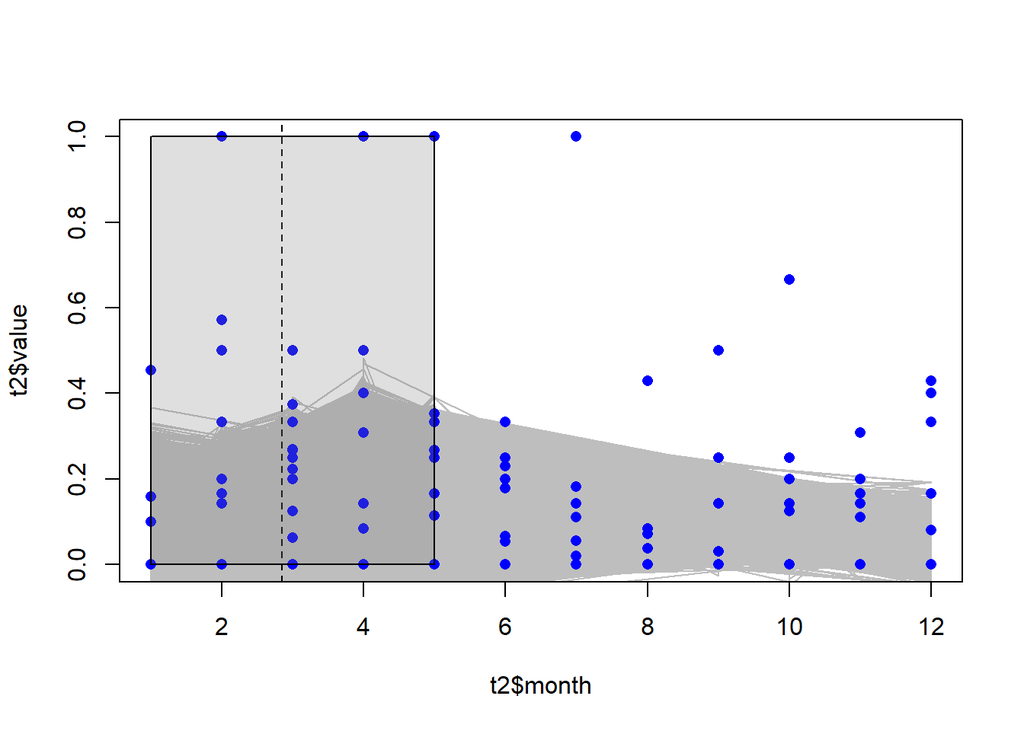

```r
post=rstan::extract(bkpt_con)$prop_mu
post=as.data.frame(post)
post=t(post)
t1=cbind(PB_gam_con$month,PB_gam_con$year, post)
t1=as.data.frame(t1)
t1=t1%>%
  rename(year=V2, month=V1)
t2=reshape2::melt(t1, id=c("year", "month"))
plot(t2$value~t2$month, type="l", col="grey", ylim=c(0,1))
points(PB_gam_con$proportion~PB_gam_con$month, col="blue", pch=16)

abline(v=2.85, col="black", lty="dashed")
rect(1,0,5,1, col = rgb(0.5,0.5,0.5,1/4))
```

### **PB exclosure plots**

```r
PB_gam_ex=PB_dat_M%>%
  filter(treatment=="exclosure")%>%
  mutate(date=as.POSIXct(paste(month, "15", year, sep="-"), format="%m-%d-%Y"))
```

**Data Visualization**

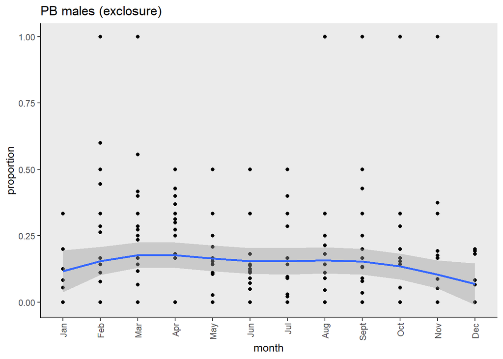

```r
ggplot(PB_gam_ex, aes(y=proportion, x=month)) +
  geom_point() +
  stat_smooth(method = 'gam', formula = y ~ s(x))+
  ggtitle("PB males (exclosure)")+
  scale_x_discrete(name="month", limits=c("Jan", "Feb", "Mar", "Apr","May", "Jun",
                                          "Jul", "Aug", "Sept", "Oct", "Nov", "Dec"))+
  theme(axis.text.x= element_text(angle = 90, vjust=0.5, hjust=1),
        panel.border = element_blank(), panel.grid.major = element_blank(),
        panel.grid.minor = element_blank(), axis.line = element_line(colour = "black"))
```

**GAM with autocorrelation structure**

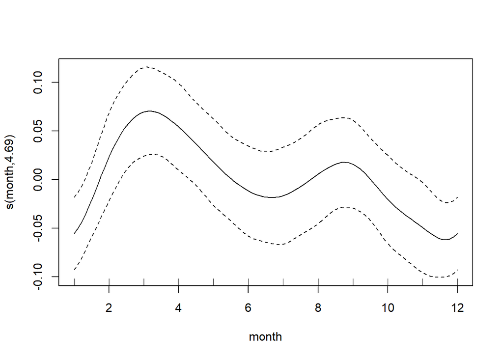

```r
m2=gamm(proportion~s(month, bs="cc", k=12), data=PB_gam_ex, correlation = corARMA(form= ~1|year, p=2))
plot(m2$gam)
```

```r
summary(m2$gam)
```

```
##
## Family: gaussian
## Link function: identity
##
## Formula:
## proportion ~ s(month, bs = "cc", k = 12)
##
## Parametric coefficients:
##             Estimate Std. Error t value Pr(>|t|)
## (Intercept)  0.13918    0.02063   6.746 1.32e-10 ***
## ---
## Signif. codes:  0 '***' 0.001 '**' 0.01 '*' 0.05 '.' 0.1 ' ' 1
##
## Approximate significance of smooth terms:
##            edf Ref.df    F  p-value
## s(month) 4.694     10 1.86 0.000843 ***
## ---
## Signif. codes:  0 '***' 0.001 '**' 0.01 '*' 0.05 '.' 0.1 ' ' 1
##
## R-sq.(adj) =  0.032
##   Scale est. = 0.042705  n = 226
```

**Calculate derivatives: to identify period of change**

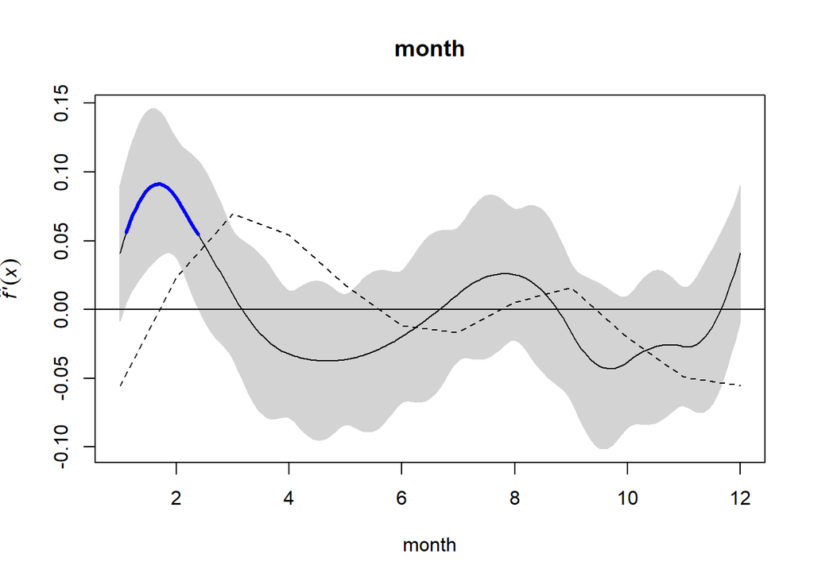

```r
want=seq(1, nrow(PB_gam_ex), length.out = 200)
pdat2=with(PB_gam_ex, data.frame(year=year[want], month=month[want]))
p3=predict(m2$gam, newdata=pdat2, type="terms", se.fit = TRUE)
pdat2=transform(pdat2, p3=p3$fit[,1], se3=p3$se.fit[,1])

df.res=df.residual(m2$gam)
crit.t=qt(0.025, df.res, lower.tail = F)
pdat2=transform(pdat2, upper=p3+(crit.t*se3), lower=p3-(crit.t*se3))

Term <- "month"
m2.d <- Deriv(m2)
m2.dci <- confint(m2.d, term = Term)
m2.dsig <- signifD(pdat2$p3, d = m2.d[[Term]]$deriv,
                     +m2.dci[[Term]]$upper, m2.dci[[Term]]$lower)

plot.Deriv(m2.d, sizer =T)

lines(pdat2$month[order(pdat2$month)], pdat2$p3[order(pdat2$month)],
       xlim=range(pdat2$month), ylim=range(pdat2$p3), pch=16,
       col="black", lty="dashed")
```

#### Notes:

*seems like Feb is the inflection period in exclosures but looking at raw data, seems like there isn’t a real “peak” period. they just reproduce whenever

```r
datlist2=list(N=length(PB_gam_ex$X),year=PB_gam_ex$years,
             month=PB_gam_ex$month, proportion=PB_gam_ex$proportion)


bkpt_ex=stan(model_code="
data {
  int<lower=1> N;                      // sample size
  vector<lower=0,upper=1>[N] proportion;        // response
  vector [N] month;                       // predictor month
  vector [N] year; // predictor year
}

parameters{
  real alpha; // intercept
  real beta1;//slope 1
  real beta2;//slope 2
  real <lower=1, upper=12>bkpt;
  real <lower=0> sigma;
  real year_eff; //year effect
}

transformed parameters{
  real prop_mu [N];

for ( i in 1:N) {
  if (month[i] < bkpt)

    prop_mu[i]=alpha+beta1* (month[i]*bkpt)+ year_eff*year[i];

  else
    prop_mu[i]= alpha+ beta2 * (month[i]*bkpt+ year_eff*year[i]);

}
  }

model {

  alpha~normal(0,10);
  beta1~ normal(0,10);
  beta2~normal (0,10);
  bkpt~ uniform(1,12);
  sigma~cauchy(0,2.5);
  year_eff~normal(0,10);
  proportion~normal(prop_mu, sigma); }

generated quantities {
real prop_mu_pred [N];

for (j in 1:N)
prop_mu_pred[j]=normal_rng(prop_mu[j],sigma);

}


", data=datlist2, chains=4, iter=1000)
```

```r
print(bkpt_ex, pars=c("alpha", "beta1", "beta2", "bkpt", "year_eff"))
```

```
## Inference for Stan model: ad66b869bcf2f4fcd33be63ddfb6149b.
## 4 chains, each with iter=1000; warmup=500; thin=1;
## post-warmup draws per chain=500, total post-warmup draws=2000.
##
##           mean se_mean   sd  2.5%   25%   50%   75% 97.5% n_eff Rhat
## alpha     0.23    0.00 0.03  0.16  0.21  0.23  0.25  0.29   658 1.00
## beta1    -0.13    0.00 0.05 -0.24 -0.16 -0.13 -0.10 -0.04   468 1.00
## beta2    -0.01    0.00 0.00 -0.02 -0.01 -0.01 -0.01  0.00   534 1.00
## bkpt      1.41    0.01 0.29  1.02  1.17  1.36  1.64  1.96   447 1.00
## year_eff -0.09    0.00 0.11 -0.30 -0.16 -0.09 -0.02  0.11   596 1.01
##
## Samples were drawn using NUTS(diag_e) at Tue Mar 02 18:14:58 2021.
## For each parameter, n_eff is a crude measure of effective sample size,
## and Rhat is the potential scale reduction factor on split chains (at
## convergence, Rhat=1).
```

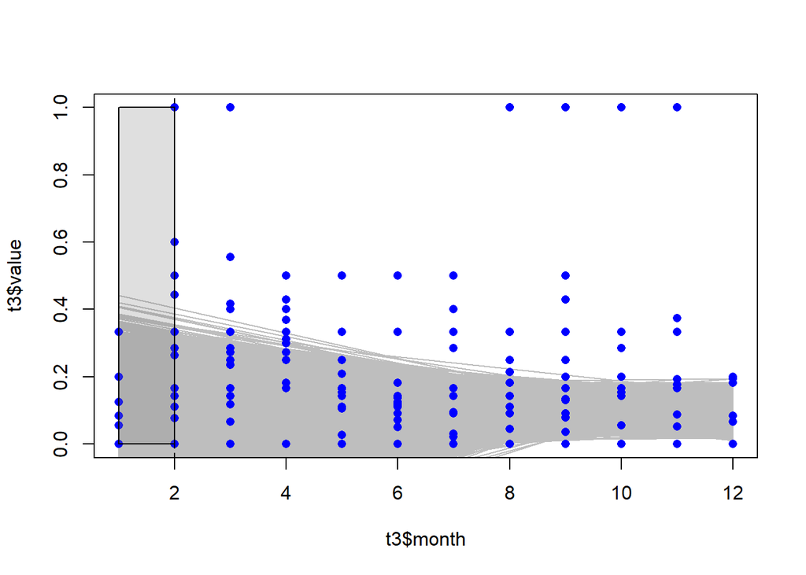

```r
post1=rstan::extract(bkpt_ex)$prop_mu
post1=as.data.frame(post1)
post1=t(post1)
t3=cbind(PB_gam_ex$month,PB_gam_ex$year, post1)
t3=as.data.frame(t3)
t3=t3%>%
  rename(year=V2, month=V1)
t3=reshape2::melt(t3, id=c("year", "month"))
plot(t3$value~t3$month, type="l", col="grey", ylim=c(0,1))
points(PB_gam_ex$proportion~PB_gam_ex$month, col="blue", pch=16)

abline(v=2, col="black", lty="dashed")
rect(1,0,2,1, col = rgb(0.5,0.5,0.5,1/4))
```